# EDA of Prosper Loan Company

### 1.可视化探索分析

### 2.建立数据模型

### 3.最终图形和摘要

### 4.总结反思

##### 背景：

2008年11月24日，SEC判定Prosper违反了《1933年证券法》，要求Prosper暂定运营。经审查后，考虑P2P借贷模型的特性，SEC将所有P2P借贷定义为债券销售，要求所有P2P企业都在SEC登记注册。2008年11月26日，加州最高法院对Prosper提起集体诉讼，控告Prosper违反加州和联邦法律发行和出售未认证和注册的证券。

2009年7月，Prosper的贷款在获得SEC的注册后，重新开发了网站。但重新开业后，竞标贷款限制在美国28个州和哥伦比亚地区的居民。有47个州的居民可以再Prosper上借款，另外三个州（Iowa、Maine、North Dakota）则不允许。

### 分析目标：

检查数据后可以发现，信用等级在2009年前后有所调整。因此本次的分析是探索：

- 容易违约的客户具有哪些特点？
- 公司信用等级调整后是否更好地反映了借款人的信用情况？

### 分析思路：

先找出与违约可能有关的变量，分析这些变量是否是对违约有影响，接着探索信用等级的变化产生的后果，最后建立违约预测模型。

| Variable | Description |  |
| --- | --- | --- |
| CreditGrade | 借款人信用评级（2009年之前） |  |
| ProsperRating (numeric/Alpha) | 信用评级（2009年之后） |  |
| LoanStatus | 贷款状态 |  |
| BorrowerRate | 借款人的贷款利率 |  |
| ListingCategory..numeric. | 贷款类型 |  |
| EmploymentStatusDuration | 借款人就业持续时间 |  |
| IsBorrowerHomeowner | 借款人是否为业主 |  |
| CreditScore | 用户信用评级机构提供的借款人的信用评级 |  |
| InquiriesLast6Months | 过去6个月征信记录 |  |
| DelinquenciesLast7Years | 过去7年拖欠次数 |  |
| BankcardUtilization | 可用循环信贷被使用的百分比 |  |
| DebtToIncomeRatio | 借款人的债务收入比 |  |
| IncomeRange | 借款人收入范围 |  |
| BorrowerState | 借款人所在州的缩写 |  |
| Occupation | 借款人职业 |  |

# 1.可视化探索分析

### 1.1单变量分析

##### 找出缺失值小于10000的变量

```
## [1] "CreditGrade"
## [1] "ProsperRating..Alpha."
## [1] "BankcardUtilization"
## [1] "BorrowerState"
## [1] "Occupation"
## [1] "DebtToIncomeRatio"
## [1] "DelinquenciesLast7Years"
## [1] "EmploymentStatus"
## [1] "EmploymentStatusDuration"
## [1] "InquiriesLast6Months"
## [1] "CreditScore"
```

##### （1）查看EmploymentStatusDuration的分布情况（虚线：中位数，实线：平均值）

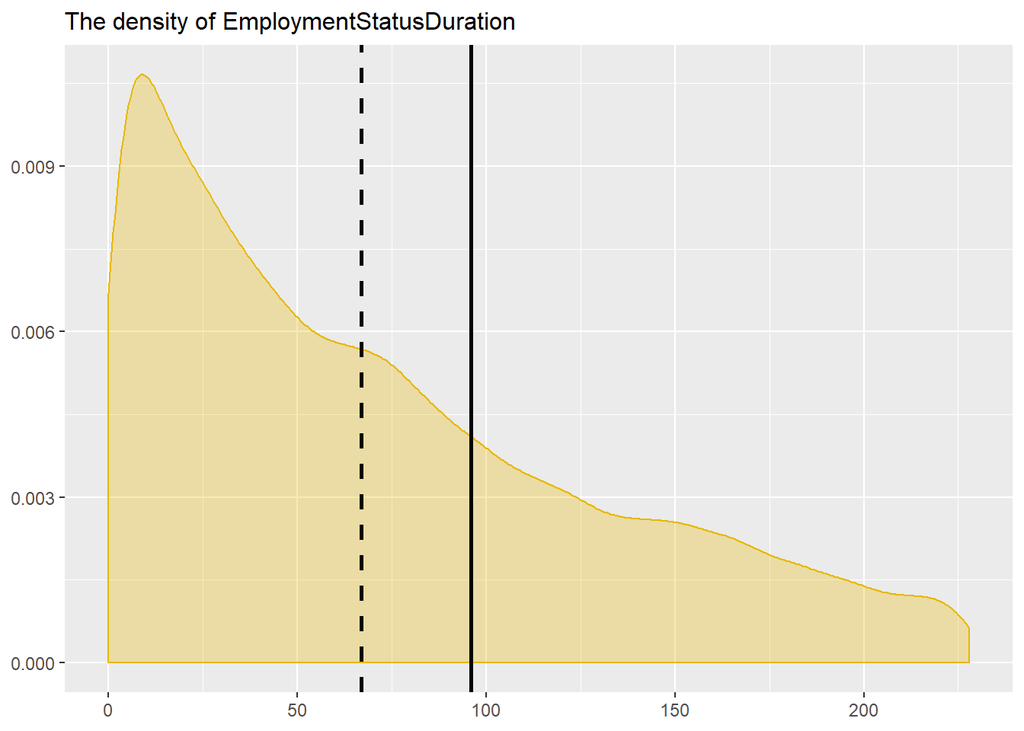

##### （2）查看CreditScore的分布情况（虚线：中位数，实线：平均值）

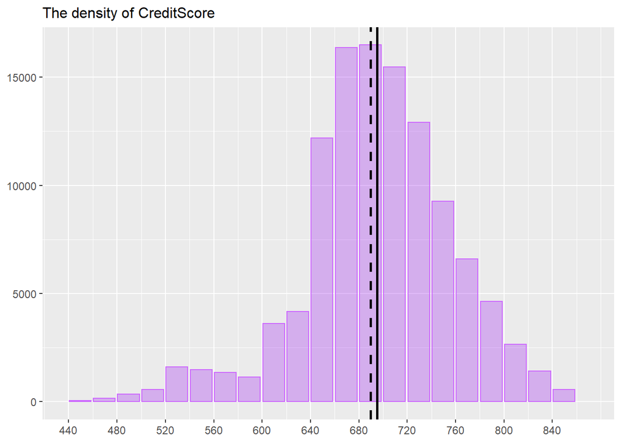

##### （3）查看InquiriesLast6Months的分布情况（虚线：中位数，实线：平均值）

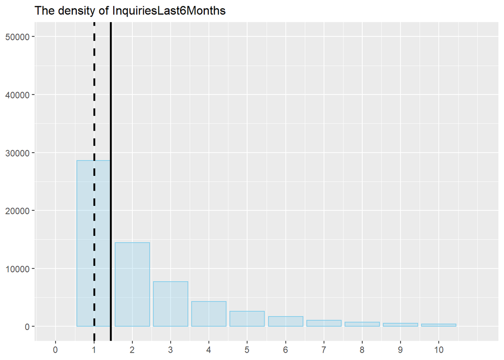

##### （4）查看DelinquenciesLast7Years的分布情况（虚线：中位数，实线：平均值）

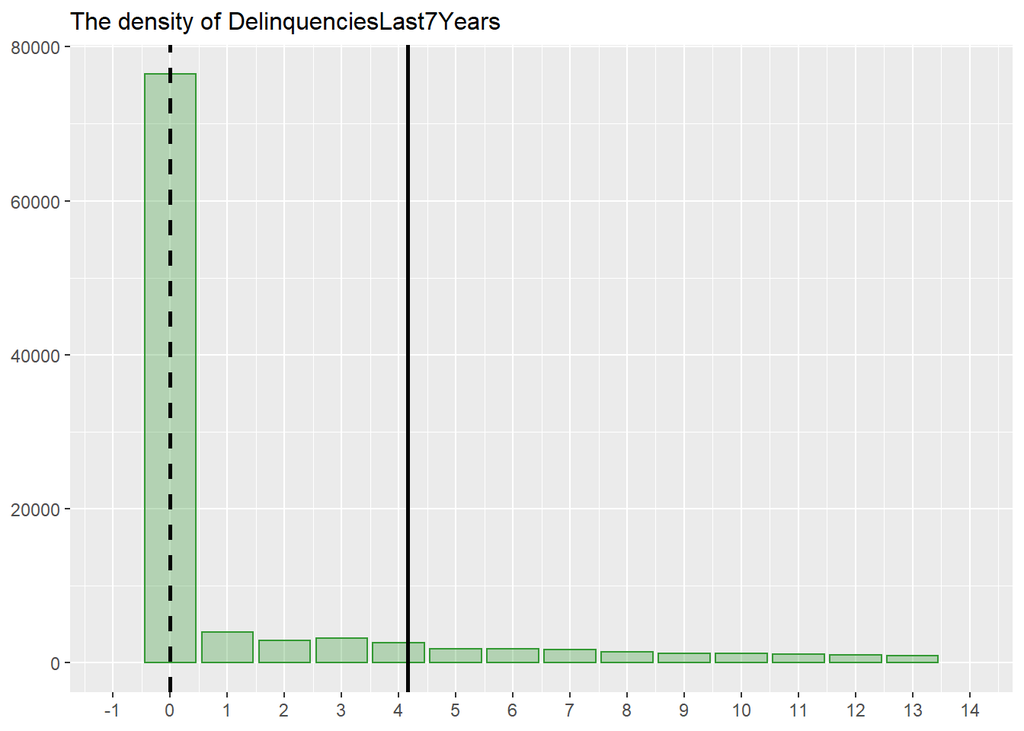

##### （5）查看BankcardUtilization的分布情况（虚线：中位数，实线：平均值）

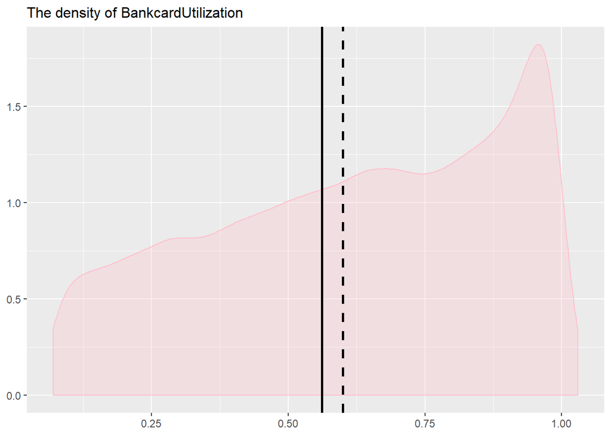

##### （6）查看DebtToIncomeRatio的分布情况（虚线：中位数，实线：平均值）

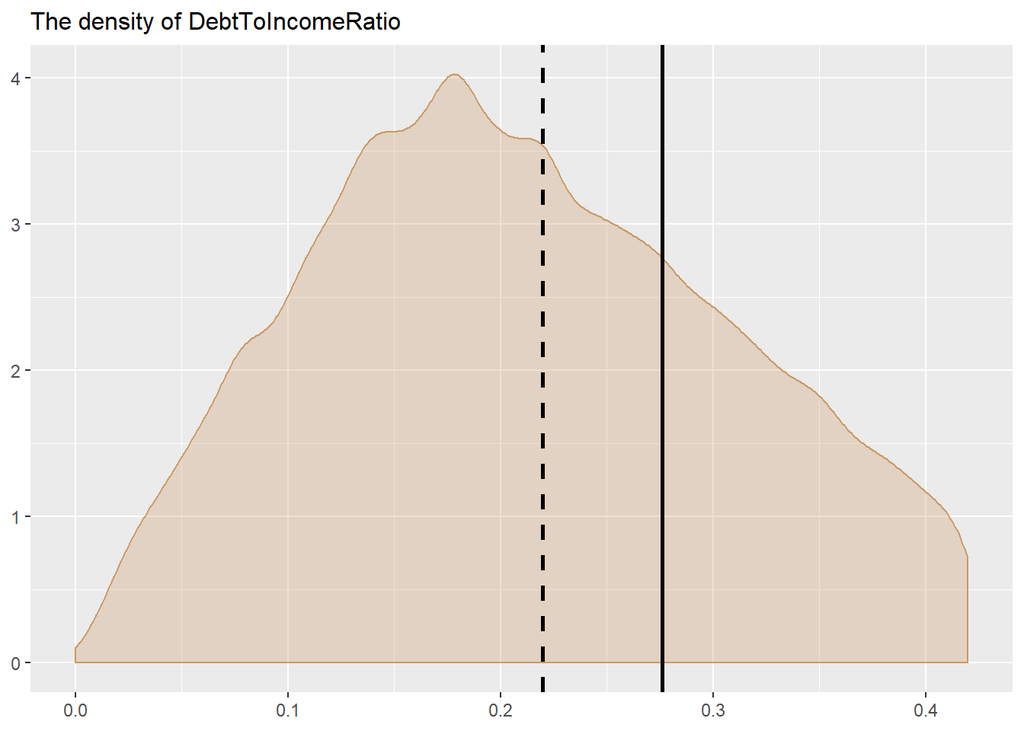

##### 根据变量的不同分布，用不同方法填充缺失值

##### 填补完缺失值后，再处理信用等级、贷款状态、收入范围等变量的数据整洁度问题

##### （7）查看两种不同的信用等级

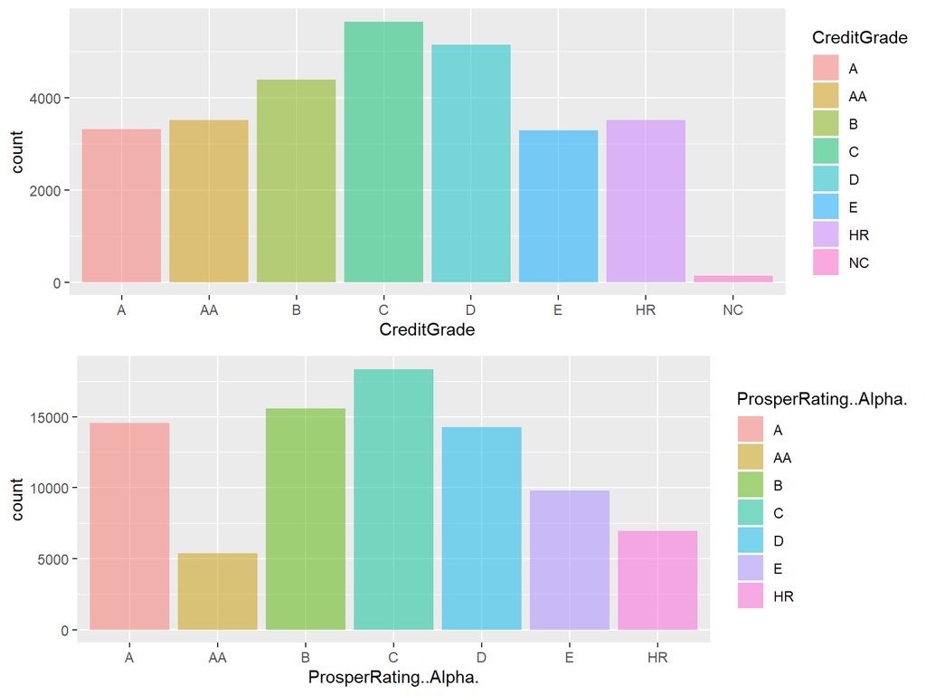

##### 2009年7月前后的信用等级制度发生了变化。之前的CreditGrade是8个等级，而之后的ProsperRate是7个等级。

##### （8）查看贷款状态的分类（去掉了“已取消”）

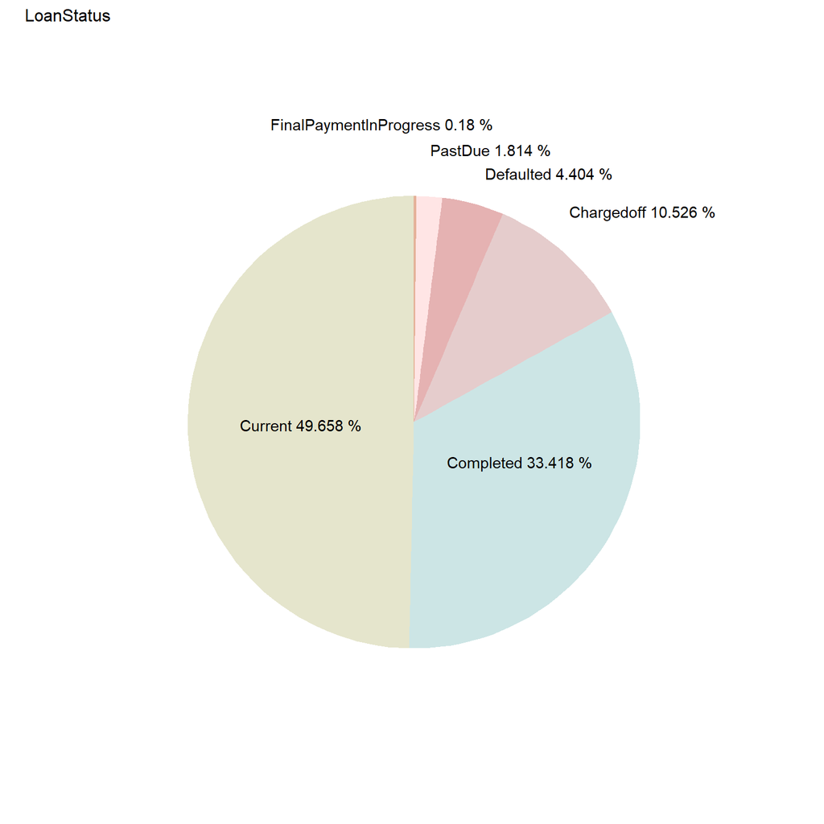

##### 蓝色系扇形代表没有违约的，红色系是以及违约的，绿色系是当前状态，无法判断是否违约。

##### 目前大部分的贷款状态是还在进行的未逾期的贷款状态：

- current占比49.65%；已完成的贷款（completed）占比33.42%
- 坏账（chargedoff）的占比10.52%
- 4.4%的贷款已经违约
- 1.8%的逾期
- 0.18%快还完贷款了
- 0.004%取消了贷款（数据太少，显示出来只有一条线，因此删掉）

##### （9）查看雇佣持续时间变量的分布情况

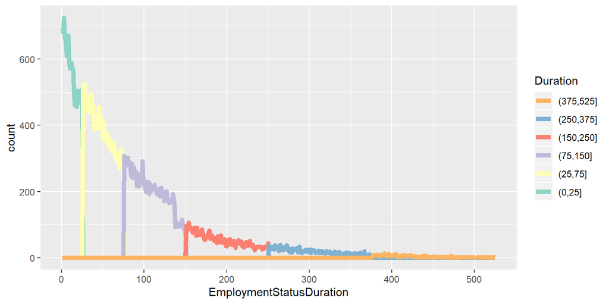

##### 从上图得知，雇佣持续时间呈现指数分布，雇佣持续时间较少的借款人数量比较多。

##### （10）查看借款人地区的分布情况

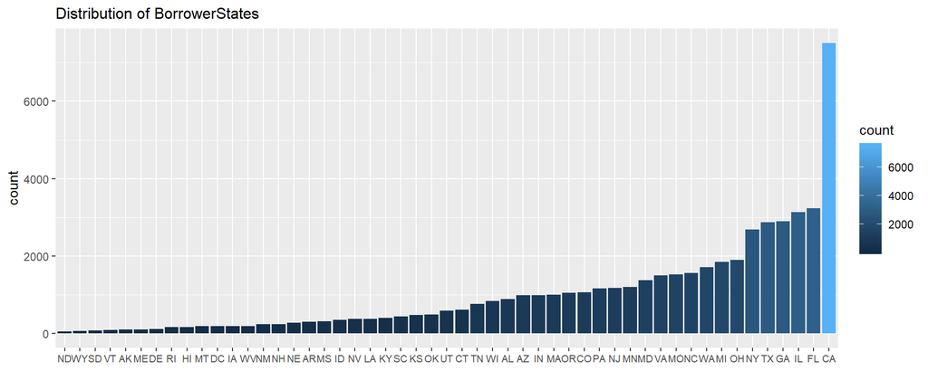

##### California，Florida，Illinois，Georgia，Texas这几个州的借款人数较多；

##### 同时North Dakota，Wyoming，Vermont，South Dakota等几个州的借款人数较少。

### 1.2双变量分析

##### （10）借款人“是否有房产”与“贷款状态”

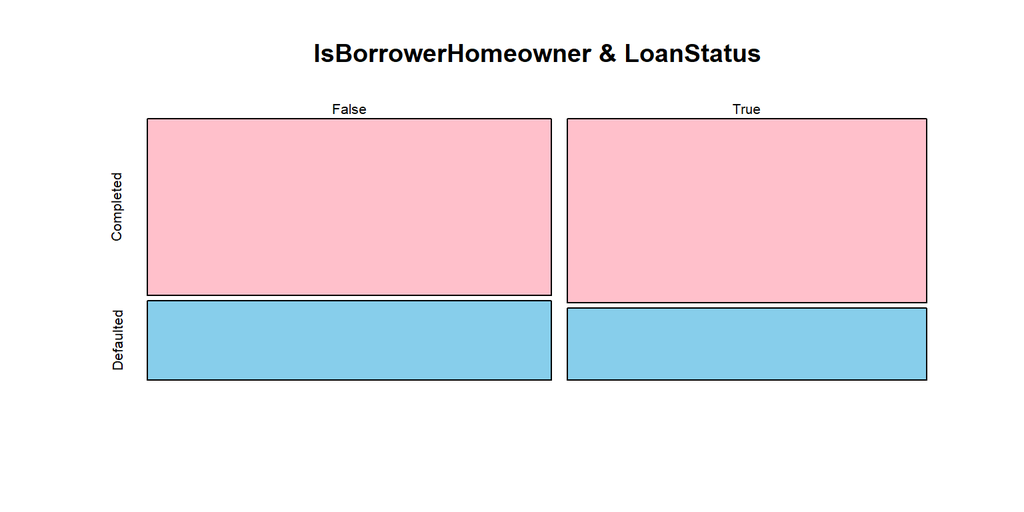

##### 有房产的借款人比没有房产的借款人的违约情况稍稍少一点。

##### （11）借款人“债务收入比率”与“贷款状态”

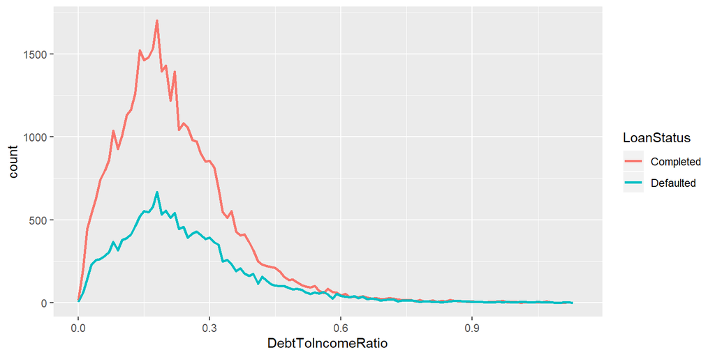

##### 目前没有看出明显的债务收入比率与贷款状态之间的关系。

##### （12）借款人“收入范围”与“贷款状态”

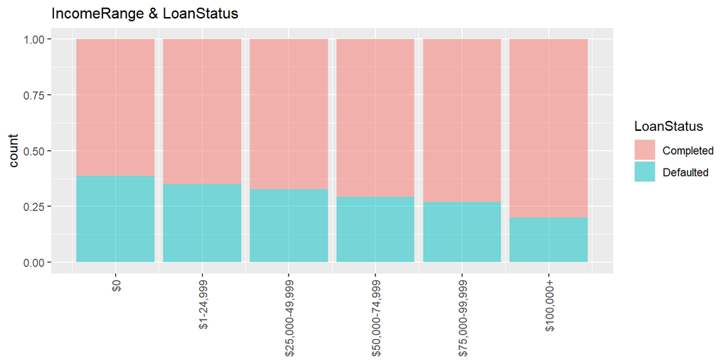

##### （13）借款人“过去6个月征信次数”，“过去7年拖欠次数”与“贷款状态”

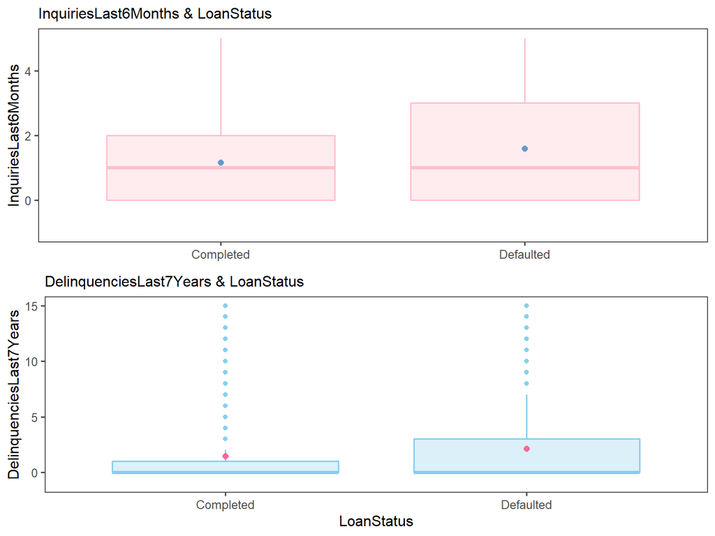

##### 违约的借款人过去6个月征信次数和过去7年拖欠次数都比没有违约的人高。

##### （14）借款人“所在地区”与“贷款状态”的分布

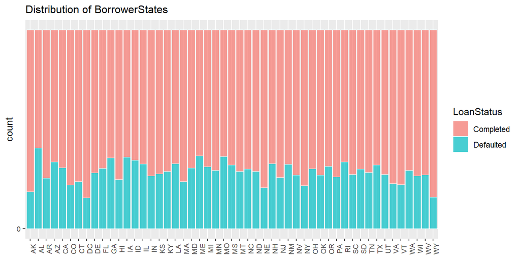

##### 来自不同的州的借款人，违约的概率也不同:

##### Alabama阿拉巴马州，Georgia乔治亚州，Iowa爱荷华州等地区的借款人具有较高的违约率。

### 1.3多变量分析

##### （15）借款人“贷款利率”、“信用分数”和“贷款状态”的关系

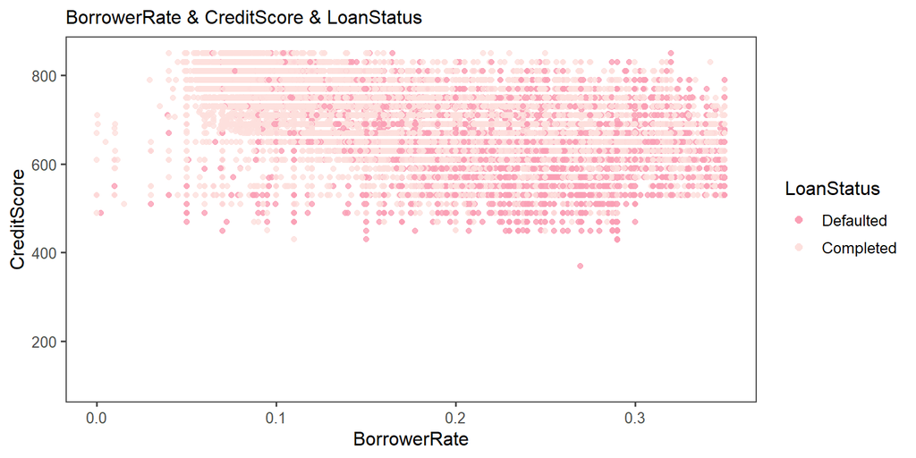

##### 从散点图分布可以看到，贷款利率较高的（图中靠右部分）违约的情况更多；而贷款利率较低的（图中靠左部分）违约的情况相对较少。

##### 同时，信用分数较高的（图中靠上方的点）违约情况比信用分数较低的（图中靠下方的点）少。

##### （16）借款人“可循环贷款使用率”、“信用等级”和“贷款状态”的关系

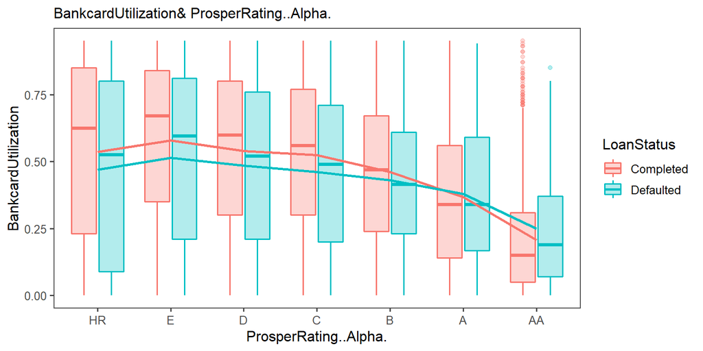

##### 因为ggplot的配色最多支持12种不同色彩分类，而贷款类别有21种类别，

##### 因此去除了0-空值和7-其它两个类别后，用两张图展示变量的关系。

| Scale1 | Scale2 |
| --- | --- |
| 0 - Not Available | 1 - Debt Consolidation |
| 2 - Home Improvement | 3 - Business |
| 4 - Personal Loan | 5 - Student Use |
| 6 - Auto | 7- Other |
| 8 - Baby&Adoption | 9 - Boat |
| 10 - Cosmetic Procedure | 11 - Engagement Ring |
| 12 - Green Loans | 13 - Household Expenses |
| 14 - Large Purchases | 15 - Medical/Dental |
| 16 - Motorcycle | 17 - RV |
| 18 - Taxes | 19 - Vacation |
| 20 - Wedding Loans |  |

##### 结合对应表格和变量分布可知，贷款类型为：Home Improvement，Personal Loan，Student Use，Cosmetic Procedure，Medical/Dental这几类的（蓝色箱线图比红色的长度较长）违约情况较多。相反，Boat，Engagement Ring，Green Loans，RV这几类贷款类型的违约情况较少。

##### 此外，Boat、Home Improvement、Business、Personal Loan、Student Use、Cosmetic Procedure、Large Purchases这几类的可循环贷款使用率较多；Motorcycle、RV、Wedding Loans这几类贷款类型的可循环贷款使用率较少。

##### （17）借款人“可用循环信贷使用率”和“贷款类型”在时间上的分布

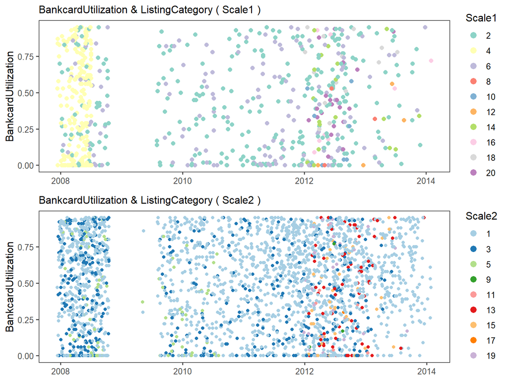

##### 贷款类型当中，数字靠后的类型，比如12 - Green Loans、13 - Household Expenses、14 - Large Purchases、

##### 15 - Medical/Dental、16 - Motorcycle、17 - RV、18 - Taxes、19 - Vacation、20 - Wedding Loans这些，在时间上的分布也比较靠后。

##### （18）借款人“过去7年拖欠次数”和“贷款状态”在时间线上的关系分布

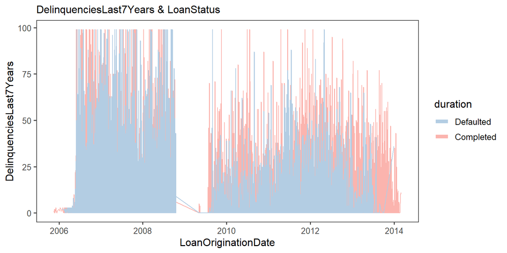

##### 可以看到数据在2009年有一个断层，而且两种分类的区别不明显，因此接下来用smooth分析两者的趋势。

##### （19）进一步计算“过去7年拖欠次数”和“贷款状态”在“2009年前后的时间线”上的关系

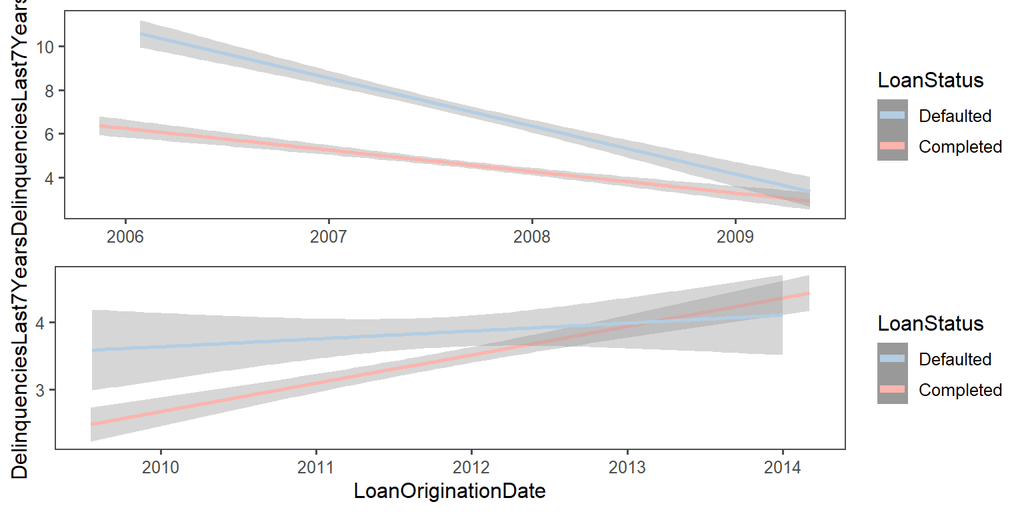

##### 因为数据在2009年有一个断层，所以分了两张图。可以看出，过去7年拖欠次数越少，违约情况也相对越少。

##### （20）借款人“雇佣持续时间”、“信用等级”、”债务收入比率“和“贷款状态”的关系

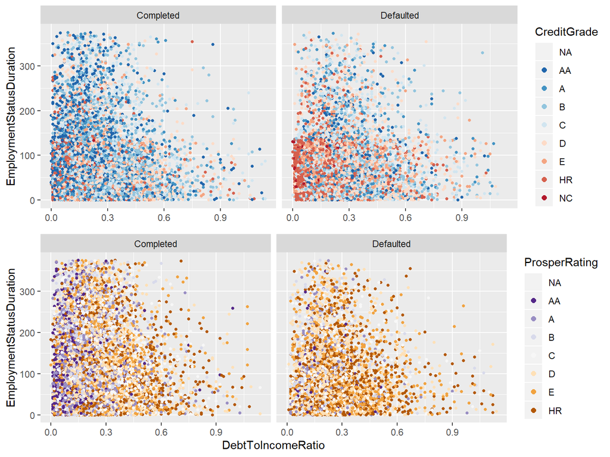

##### 就是违约情况中，有不少信用评级较高的点（蓝色），并且有些聚集在债务收入比较高的地方。按常理来讲，信用评级高的人，不容易违约，债务收入比率通常也较低。

##### 2009年7月之后的信用评级的图就不存在异常了，违约情况中，几乎很少存在信用评级较高的人（紫色），同时，信用评级较高的点（紫色）分布的位置对应者较低的债务收入比率。

### 经过以上的可视化，找出了与违约率相关的变量：

- BorrowerRate
- EmploymentStatusDuration
- DebtToIncomeRatio
- BankcardUtilization
- DelinquenciesLast7Years
- CreditScore

##### 现在用这几个变量建立模型，探索信用等级变化对公司评价借款人信用情况的能力。

# 2.建立数据模型

### 2.1信用等级：线性回归模型

##### 查看连续变量的相关关系

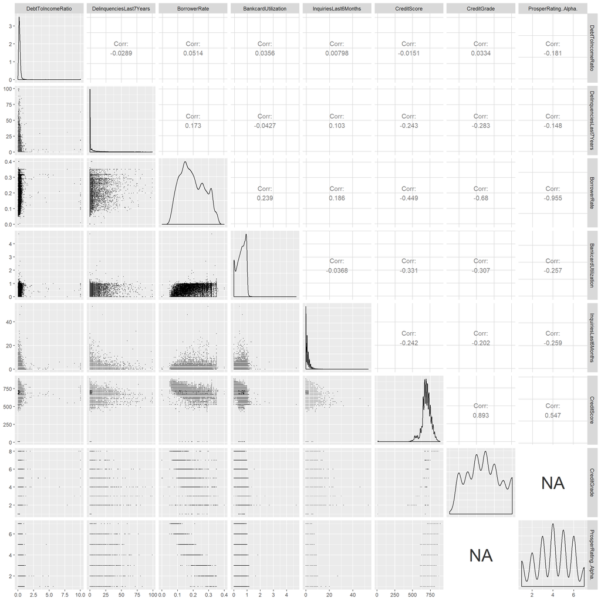

##### 2009年7月之前的信用等级

```
##
## Calls:
## m1: lm(formula = I(CreditGrade) ~ I(CreditScore), data = dt)
## m2: lm(formula = I(CreditGrade) ~ I(CreditScore) + DelinquenciesLast7Years,
##     data = dt)
## m3: lm(formula = I(CreditGrade) ~ I(CreditScore) + DelinquenciesLast7Years +
##     BankcardUtilization, data = dt)
## m4: lm(formula = I(CreditGrade) ~ I(CreditScore) + DelinquenciesLast7Years +
##     BankcardUtilization + InquiriesLast6Months, data = dt)
## m5: lm(formula = I(CreditGrade) ~ I(CreditScore) + DelinquenciesLast7Years +
##     BankcardUtilization + InquiriesLast6Months + BorrowerRate,
##     data = dt)
##
## ==================================================================================================
##                                 m1             m2            m3            m4            m5
## --------------------------------------------------------------------------------------------------
##   (Intercept)                  -7.061***     -6.817***     -6.323***     -6.176***     -3.849***
##                                (0.033)       (0.034)       (0.038)       (0.039)       (0.048)
##   I(CreditScore)                0.018***      0.018***      0.018***      0.017***      0.015***
##                                (0.000)       (0.000)       (0.000)       (0.000)       (0.000)
##   DelinquenciesLast7Years                    -0.009***     -0.010***     -0.010***     -0.006***
##                                              (0.000)       (0.000)       (0.000)       (0.000)
##   BankcardUtilization                                      -0.388***     -0.388***     -0.265***
##                                                            (0.014)       (0.014)       (0.013)
##   InquiriesLast6Months                                                   -0.019***     -0.006***
##                                                                          (0.001)       (0.001)
##   BorrowerRate                                                                         -5.294***
##                                                                                        (0.072)
## --------------------------------------------------------------------------------------------------
##   adj. R-squared                0.826         0.829         0.834         0.835         0.861
##   F                        137640.161     70376.816     48387.728     36663.664     35940.446
##   AIC                       67749.835     67214.966     66473.536     66227.777     61237.122
## ==================================================================================================
##   Significance: *** = p < 0.001; ** = p < 0.01; * = p < 0.05
```

##### 2009年7月之后的信用等级

```r
m1 <- lm(I(ProsperRating..Alpha.)~ I(CreditScore), data = dt)
m2 <- update(m1, ~ . + DelinquenciesLast7Years)
m3 <- update(m2, ~ . + BankcardUtilization)
m4 <- update(m3, ~ . + InquiriesLast6Months)
m5 <- update(m4, ~ . + BorrowerRate)

mtable(m1, m2, m3, m4, m5,
       summary.stats=c("adj. R-squared","F","AIC"))
```

```
##
## Calls:
## m1: lm(formula = I(ProsperRating..Alpha.) ~ I(CreditScore), data = dt)
## m2: lm(formula = I(ProsperRating..Alpha.) ~ I(CreditScore) + DelinquenciesLast7Years,
##     data = dt)
## m3: lm(formula = I(ProsperRating..Alpha.) ~ I(CreditScore) + DelinquenciesLast7Years +
##     BankcardUtilization, data = dt)
## m4: lm(formula = I(ProsperRating..Alpha.) ~ I(CreditScore) + DelinquenciesLast7Years +
##     BankcardUtilization + InquiriesLast6Months, data = dt)
## m5: lm(formula = I(ProsperRating..Alpha.) ~ I(CreditScore) + DelinquenciesLast7Years +
##     BankcardUtilization + InquiriesLast6Months + BorrowerRate,
##     data = dt)
##
## ======================================================================================================
##                                 m1             m2             m3             m4             m5
## ------------------------------------------------------------------------------------------------------
##   (Intercept)                  -9.751***      -9.571***      -9.073***      -7.783***       6.085***
##                                (0.072)        (0.075)        (0.089)        (0.087)        (0.037)
##   I(CreditScore)                0.020***       0.019***       0.019***       0.017***       0.003***
##                                (0.000)        (0.000)        (0.000)        (0.000)        (0.000)
##   DelinquenciesLast7Years                     -0.005***      -0.006***      -0.005***      -0.000
##                                               (0.001)        (0.001)        (0.001)        (0.000)
##   BankcardUtilization                                        -0.181***      -0.407***      -0.095***
##                                                              (0.018)        (0.018)        (0.006)
##   InquiriesLast6Months                                                      -0.276***      -0.033***
##                                                                             (0.003)        (0.001)
##   BorrowerRate                                                                            -20.195***
##                                                                                            (0.027)
## ------------------------------------------------------------------------------------------------------
##   adj. R-squared                0.301          0.302          0.303          0.354          0.915
##   F                         36583.731      18364.121      12291.220      11645.312     182084.582
##   AIC                      297746.117     297646.898     297547.163     291037.945     119250.203
## ======================================================================================================
##   Significance: *** = p < 0.001; ** = p < 0.01; * = p < 0.05
```

##### 2009年信用等级的可决系数是0.861，2009年7月之后的可决系数为0.915，说明模型拟合度都比较好；

##### 并且之后的信用等级拟合度比之前的高，说明2009年07月后的信用等级比之前的能更好地反映借款人的信用。

### 2.2 建立随机森林预测模型

##### 既然调整后的信用等级更好，对违约率的建模也基于2009年7月之后的数据进行。

##### 分割训练集和测试集

```
##
## Completed Defaulted
##     15356      4439
```

```
##
## Completed Defaulted
##      6580      1902
```

##### 影响因素重要程度排序

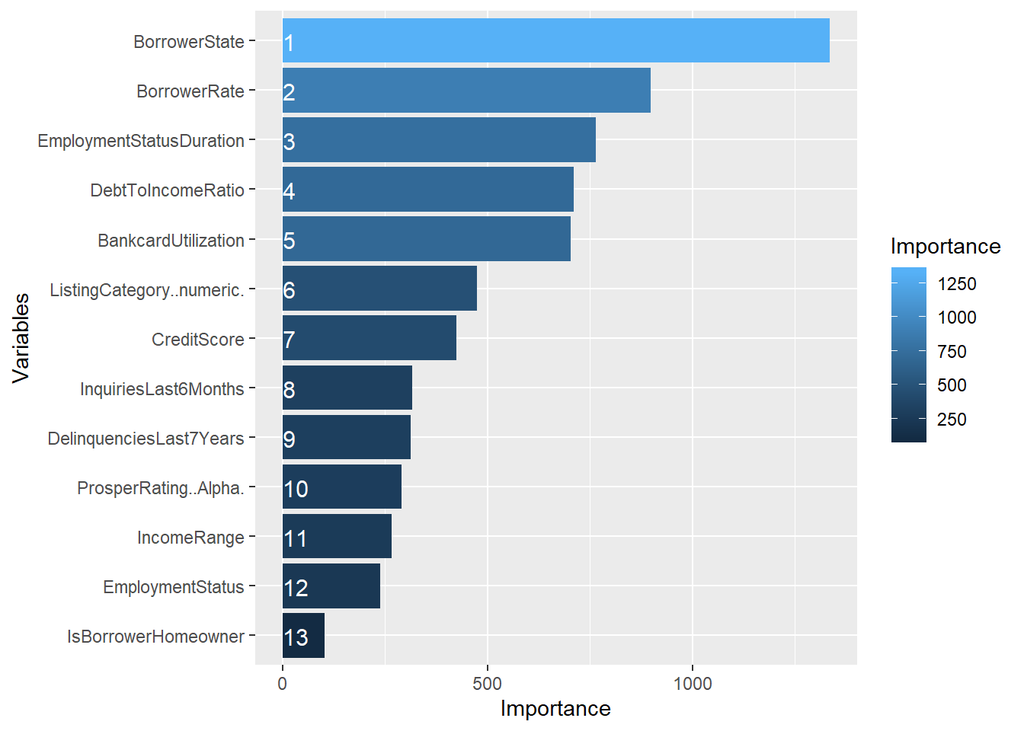

##### 模型运行结果及准确率

```
##            predit
##             Completed Defaulted
##   Completed      6194       386
##   Defaulted      1608       294
```

```
## [1] 0.7649139
```

##### 模型准确率约为0.77

# 3.最终图形和摘要

### 3.1 借款人“所在州”、“过去6个月征信次数”、“过去7年拖欠次数”与“贷款状态”的关系

##### 图1 ：Distribution of BorrowerStates

California，Florida，Illinois，Georgia，Texas这几个州的借款人数较多；同时North Dakota，Wyoming，Vermont，South Dakota等几个州的借款人数较少。

##### 图2 ：BorrowerStates & LoanStatus

来自不同的州的借款人，违约的概率也不同: Alabama阿拉巴马州， Georgia乔治亚州，Iowa爱荷华州等地区的借款人具有较高的违约率。

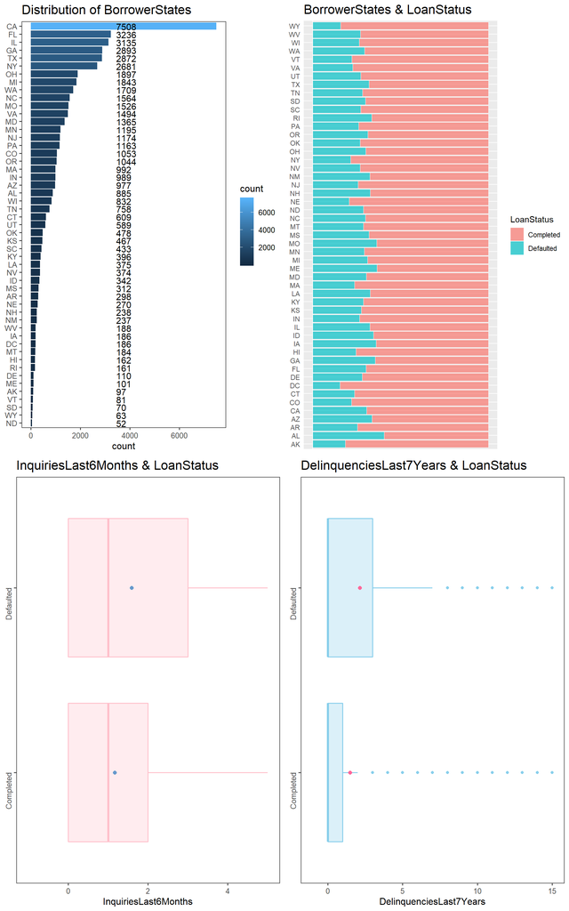

##### 图3 ：InquiriesLast6Months & LoanStatus

##### 图4 ：DelinquenciesLast7Years & LoanStatus

违约的借款人过去6个月征信次数和过去7年拖欠次数都比没有违约的人高。

### 3.2 贷款状态分类以及借款人“贷款利率”、“信用分数”和“贷款状态”的关系

##### 图1 ：LoanStatus Category and Proportion

蓝色系扇形代表没有违约的，红色系是以及违约的，绿色系是当前状态，无法判断是否违约。目前大部分的贷款状态是还在进行的未逾期的贷款状态，current占比49.65%；已完成的贷款（completed）占比33.42%，坏账（chargedoff）的占比10.52%；其它情况有：4.4%的贷款已经违约，1.8%的逾期，0.18%快还完贷款了，还有0.004%取消了贷款（数据太少，显示出来只有一条线，因此删掉。）

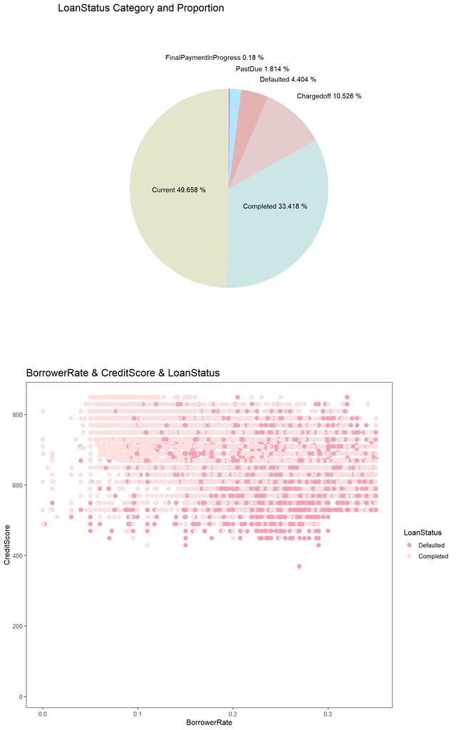

##### 图2 ：BorrowerRate & CreditScore & LoanStatus

从散点图分布可以看到，贷款利率较高的（图中靠右部分）违约的情况更多；而贷款利率较低的（图中靠左部分）违约的情况相对较少。同时，信用分数较高的（图中靠上方的点）违约情况比信用分数较低的（图中靠下方的点）少。

### 3.3 借款人“雇佣持续时间”、“信用等级”、“债务收入比率”以及

### （“可循环贷款使用率”、“贷款类型”与“贷款状态”的关系

##### 图2 ：EmploymentStatusDuration & DebtToIncomeRatio & ProsperRating

2009年7月之后的信用评级的图就不存在异常了，违约情况中，几乎很少存在信用评级较高的人（紫色），同时，信用评级较高的点（紫色）分布的位置对应者较低的债务收入比率。

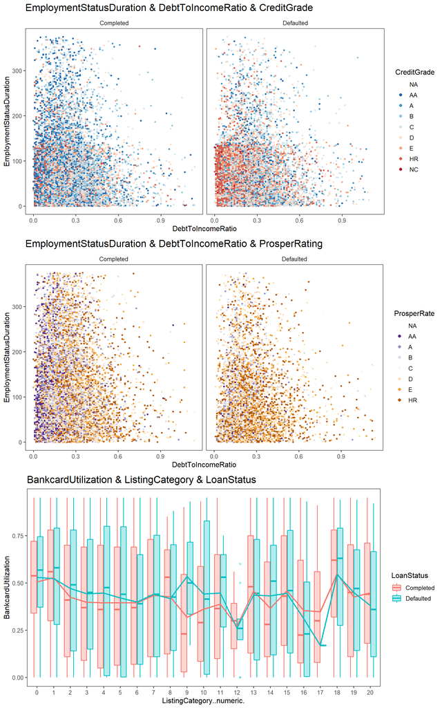

##### 图3 ：BankcardUtilization & ListingCategory & LoanStatus

因为ggplot的配色最多支持12种不同色彩分类，而贷款类别有21种类别，因此去除了0-空值和7-其它两个类别后，用两张图展示变量的关系。

| Scale1 | Scale2 |
| --- | --- |
| 0 - Not Available | 1 - Debt Consolidation |
| 2 - Home Improvement | 3 - Business |
| 4 - Personal Loan | 5 - Student Use |
| 6 - Auto | 7- Other |
| 8 - Baby&Adoption | 9 - Boat |
| 10 - Cosmetic Procedure | 11 - Engagement Ring |
| 12 - Green Loans | 13 - Household Expenses |
| 14 - Large Purchases | 15 - Medical/Dental |
| 16 - Motorcycle | 17 - RV |
| 18 - Taxes | 19 - Vacation |
| 20 - Wedding Loans |  |

结合对应表格和变量分布可知，贷款类型为：Home Improvement，Personal Loan，Student Use，Cosmetic Procedure，Medical/Dental这几类的（蓝色箱线图比红色的长度较长）违约情况较多。相反，Boat，Engagement Ring，Green Loans，RV这几类贷款类型的违约情况较少。

此外，Boat、Home Improvement、Business、Personal Loan、Student Use、Cosmetic Procedure、Large Purchases这几类的可循环贷款使用率较多； Motorcycle、RV、Wedding Loans这几类贷款类型的可循环贷款使用率较少。

# 4.总结反思

### 1. 总结

##### 本次分析汇总了最终图形和摘要，并回答了开头的2个问题：

（1）容易违约的客户具有哪些特点？

通过变量之间的可视化分析，筛选出了违约的客户具有的特点： 借款人所在地区，贷款利率，受雇佣的持续时间，债务收入的比率，可循环贷款使用率，贷款类型，信用分数；并根据历史数据建立一个准确度约为0.77的预测模型。

（2）公司信用等级调整后是否更好地反映了借款人的信用情况？

通过建立线性模型，发现2009年信用等级的可决系数是0.861，2009年7月之后的可决系数为0.915，说明模型拟合度都比较好；并且之后的信用等级拟合度比之前的高，新的信用等级确实能更好地判断借款人的信用情况。

### 2. 反思

- 缺失值的处理还有待提高：
- 数据建模理论知识有待完善和补充。
- 本来还可以分析得更深入，但是时间和精力有限。

### 参考文献：

##### https://blog.csdn.net/weixin_41100555/article/details/80033035

##### https://zhuanlan.zhihu.com/p/27288744

##### https://zhuanlan.zhihu.com/p/32324410

##### https://zhuanlan.zhihu.com/p/28342576

##### https://www.jianshu.com/p/6eb58b0be7c8

##### https://blog.csdn.net/gxhzoe/article/details/80498691